# Topic 2 - Regression - lab

MSDA7003 - Machine Learning

KT Wong

Faculty of Social Sciences, HKU

2024-09-20

The materials in this topic are drawn from Lantz (2023) and James et al. (2023)

# Tutorial lab

Linear Regression - predict automobile vehicle insurance claims costs

## Motivation

- insurers invest time and money to develop models that accurately forecast claims costs for the insured population
  - This is the field known as actuarial science
  - uses sophisticated statistical techniques to estimate risk
- If the expense estimates for each risk segment are correct
  - the insurance company can price the insurance premiums lower for segments with less risk
  - and potentially attract new, low-risk customers from competing insurance companies

## Step 1 - collect data

- a simulation based on demographics and traffic statistics from the United States government
  - approximate the real-world conditions of automobile insurance companies in the U.S. state of Michigan
    - home to about ten million residents and seven million licensed drivers
- 20,000 cases of beneficiaries enrolled in the hypothetical automobile vehicle insurance plan
- Each case represents an insured individual’s characteristics and total insurance claims costs (expenses) charged to the plan for the calendar year
- each of the 20,000 beneficiaries enrolled in a “safe driving discount” program
  - required the use of a device or mobile phone application
  - monitor safe driving conditions throughout the year

## Step 1 - collect data

- The features available at the time of enrollment are:
  - age: The age of the driver, from 16 to 89
  - geo_area: The geographic area of the vehicle owner’s primary residence
    - the place where the vehicle will be used most often
  - est_value: The estimated market value of the vehicle(s)
  - vehicle_type: The type of passenger vehicle, either a car, truck, minivan, or sport utility vehicle (SUV)
  - miles_driven: The distance driven (in miles) in the calendar year
  - college_grad_ind: A binary indicator set to 1 if the beneficiary has a college education or higher
  - speeding_ticket_ind: A binary indicator set to 1 if a speeding ticket or infraction was received during the past five years
  - clean_driving_ind: A binary indicator set to 1 if no at-fault insurance claims were paid during the past five years

## More varaibles

- the following two additional predictors, which are intended to reflect more risky driving behaviors:
  - hard_braking_ind
    - A binary indicator set to 1 if the vehicle frequently applies “hard brakes”
  - late_driving_ind
    - A binary indicator set to 1 if the vehicle is driven regularly after midnight
- A regression model will help us disentangle relationships among those variables
- It requires us to specify the connections between the features ourselves
  - vs detecting them automatically

## Step 2 - Explore and prepare the data

```r
library(tidyverse)
insurance<- read_csv('https://raw.githubusercontent.com/kwan-MSDA/MSDA7003/main/autoinsurance.csv')

insurance<- insurance %>%
  mutate_if(is.character, as.factor)

str(insurance)
```

```
tibble [20,000 × 11] (S3: tbl_df/tbl/data.frame)
 $ age                : num [1:20000] 19 30 39 64 33 27 62 39 67 38 ...
 $ geo_area           : Factor w/ 3 levels "rural","suburban",..: 3 3 3 2 2 2 2 3 1 3 ...
 $ vehicle_type       : Factor w/ 4 levels "car","minivan",..: 3 3 1 3 3 3 1 4 1 1 ...
 $ est_value          : num [1:20000] 28811 52603 113870 35228 19190 ...
 $ miles_driven       : num [1:20000] 11700 12811 9784 17400 14665 ...
 $ college_grad_ind   : num [1:20000] 0 1 1 0 0 1 1 0 1 1 ...
 $ speeding_ticket_ind: num [1:20000] 1 0 0 0 0 0 0 0 0 0 ...
 $ hard_braking_ind   : num [1:20000] 1 0 0 0 0 0 0 0 0 0 ...
 $ late_driving_ind   : num [1:20000] 0 0 0 0 0 0 0 0 0 0 ...
 $ clean_driving_ind  : num [1:20000] 0 1 0 1 1 0 1 1 0 1 ...
 $ expenses           : num [1:20000] 0 6311 49684 0 0 ...
```

```r
summary(insurance$expenses)
```

```
   Min. 1st Qu.  Median    Mean 3rd Qu.    Max.
      0       0       0    1709       0  232797
```

## Step 2 - Explore and prepare the data

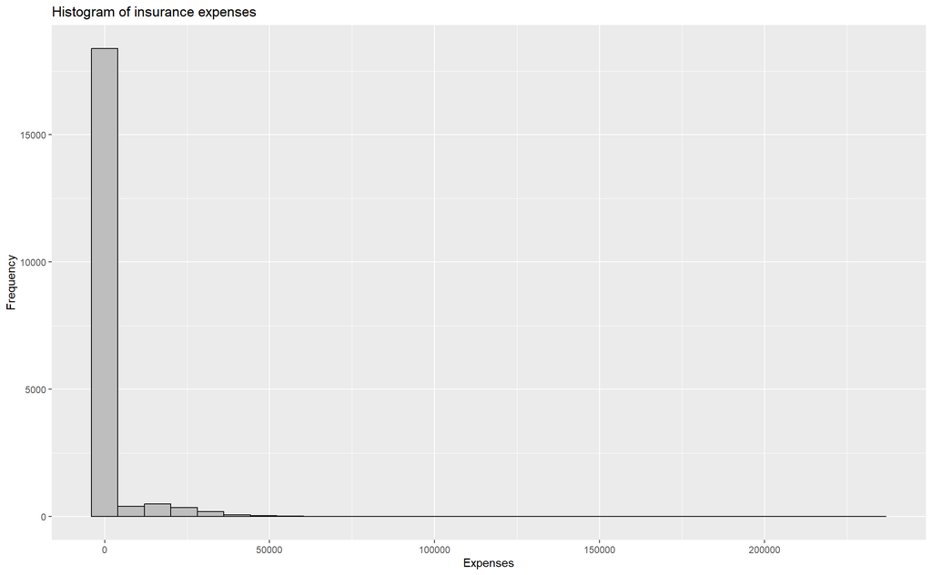

```r
library(ggplot2)

ggplot(insurance,aes(x=expenses)) +
  geom_histogram(fill='grey', color="black")+
  labs(title="Histogram of insurance expenses",
        x= "Expenses", y="Frequency")
```

## Explore the data a bit more

```r
table(insurance$geo_area)
```

```
   rural suburban    urban
    3622     8727     7651
```

```r
table(insurance$vehicle_type)
```

```
    car minivan     suv   truck
   5801     726    9838    3635
```

```r
# Exploring relationships between features using the correlation matrix

cor(insurance[c("age", "est_value", "miles_driven", "expenses")])
```

```
                      age   est_value miles_driven     expenses
age           1.000000000 -0.05990552   0.04812638 -0.009121269
est_value    -0.059905524  1.00000000  -0.01804807  0.088100468
miles_driven  0.048126376 -0.01804807   1.00000000  0.062146507
expenses     -0.009121269  0.08810047   0.06214651  1.000000000
```

## Visualizing relationships between features – the scatterplot matrix

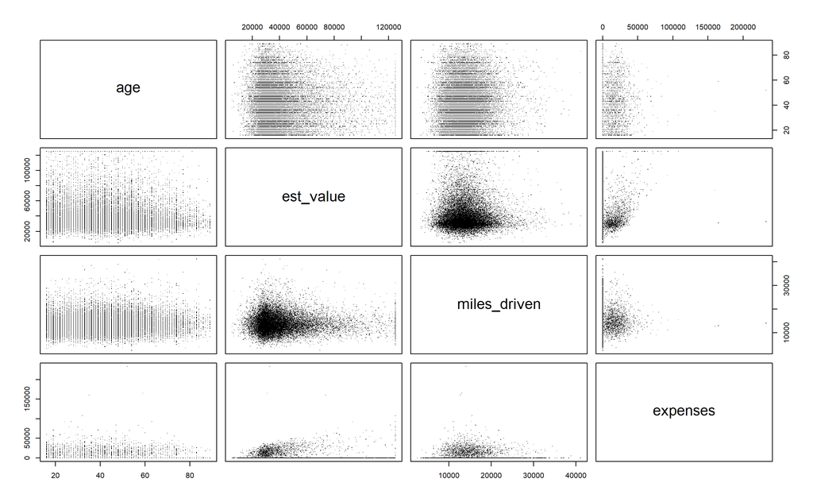

```r
pairs(insurance[c("age", "est_value", "miles_driven", "expenses")], pch=".")
```

## Visualizing relationships between features – the scatterplot matrix

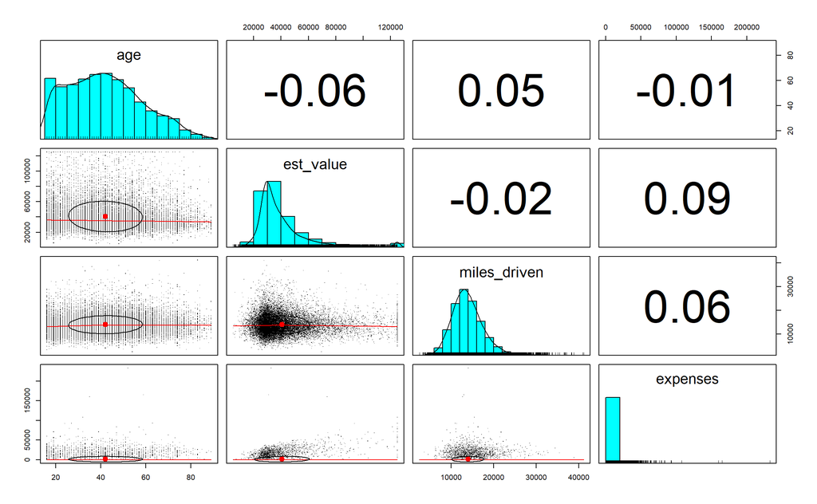

```r
#install.packages("psych")

library(psych)

pairs.panels(insurance[c("age", "est_value", "miles_driven", "expenses")], pch=".")
```

## Step 3 - Training a model

### run a regression model

```r
ins_model<- lm(expenses~ age + geo_area + vehicle_type +
                 est_value + miles_driven +
                 college_grad_ind + speeding_ticket_ind +
                 hard_braking_ind + late_driving_ind +
                 clean_driving_ind,
               data=insurance)

options(scipen=999)

summary(ins_model)
```

```
Call:
lm(formula = expenses ~ age + geo_area + vehicle_type + est_value +
    miles_driven + college_grad_ind + speeding_ticket_ind + hard_braking_ind +
    late_driving_ind + clean_driving_ind, data = insurance)

Residuals:
   Min     1Q Median     3Q    Max
 -6707  -1989  -1492  -1057 231252

Coefficients:
                        Estimate   Std. Error t value             Pr(>|t|)
(Intercept)         -1154.914856   351.370732  -3.287              0.00101 **
age                    -1.886027     3.144556  -0.600              0.54866
geo_areasuburban      191.078953   143.199245   1.334              0.18210
geo_areaurban         169.114255   157.850516   1.071              0.28402
vehicle_typeminivan   115.278619   276.579845   0.417              0.67683
vehicle_typesuv       -19.695001   117.990151  -0.167              0.86743
vehicle_typetruck      21.568360   153.630939   0.140              0.88835
est_value               0.031145     0.002497  12.475 < 0.0000000000000002 ***
miles_driven            0.118986     0.014327   8.305 < 0.0000000000000002 ***
college_grad_ind      -25.040302   115.578315  -0.217              0.82848
speeding_ticket_ind   155.824097   140.155213   1.112              0.26624
hard_braking_ind       11.845220   106.912005   0.111              0.91178
late_driving_ind      362.485502   224.655385   1.614              0.10665
clean_driving_ind    -239.047399   111.076229  -2.152              0.03140 *
---
Signif. codes:  0 '***' 0.001 '**' 0.01 '*' 0.05 '.' 0.1 ' ' 1

Residual standard error: 6995 on 19986 degrees of freedom
Multiple R-squared:  0.01241,   Adjusted R-squared:  0.01176
F-statistic: 19.31 on 13 and 19986 DF,  p-value: < 0.00000000000000022
```

## Step 4 - evaluate model performance

```r
library(sjPlot)
library(sjmisc)
library(sjlabelled)
library(sjstats)

ins_model<- lm(expenses~ .,
               data=insurance)

ins_model %>% tab_model()
```

|  | expenses |  |  |
| --- | --- | --- | --- |
| Predictors | Estimates | CI | p |
| (Intercept) | -1154.91 | -1843.63 – -466.20 | **0.001** |
| age | -1.89 | -8.05 – 4.28 | 0.549 |
| geo area [suburban] | 191.08 | -89.60 – 471.76 | 0.182 |
| geo area [urban] | 169.11 | -140.29 – 478.51 | 0.284 |
| vehicle type [minivan] | 115.28 | -426.84 – 657.40 | 0.677 |
| vehicle type [suv] | -19.70 | -250.97 – 211.58 | 0.867 |
| vehicle type [truck] | 21.57 | -279.56 – 322.70 | 0.888 |
| est value | 0.03 | 0.03 – 0.04 | **<0.001** |
| miles driven | 0.12 | 0.09 – 0.15 | **<0.001** |
| college grad ind | -25.04 | -251.58 – 201.50 | 0.828 |
| speeding ticket ind | 155.82 | -118.89 – 430.54 | 0.266 |
| hard braking ind | 11.85 | -197.71 – 221.40 | 0.912 |
| late driving ind | 362.49 | -77.86 – 802.83 | 0.107 |
| clean driving ind | -239.05 | -456.77 – -21.33 | **0.031** |
| Observations | 20000 |  |  |
| R<sup>2</sup> / R<sup>2</sup> adjusted | 0.012 / 0.012 |  |  |

## Step 5 - Improve model performance

- adding a nonlinear relationship for age
- adding interaction effects

```r
insurance$age2<- insurance$age^2

ins_model2<- lm(expenses ~ .+ hard_braking_ind:late_driving_ind,
                data=insurance)

summary(ins_model2)
```

```
Call:
lm(formula = expenses ~ . + hard_braking_ind:late_driving_ind,
    data = insurance)

Residuals:
   Min     1Q Median     3Q    Max
 -6618  -1996  -1491  -1044 231358

Coefficients:
                                     Estimate  Std. Error t value
(Intercept)                       -535.038171  457.146614  -1.170
age                                -33.142400   15.366892  -2.157
geo_areasuburban                   178.825158  143.305863   1.248
geo_areaurban                      132.463265  158.726709   0.835
vehicle_typeminivan                171.715580  277.946530   0.618
vehicle_typesuv                     -8.006108  118.116633  -0.068
vehicle_typetruck                   26.426396  153.650455   0.172
est_value                            0.031179    0.002496  12.489
miles_driven                         0.118748    0.014327   8.289
college_grad_ind                    17.248581  117.398583   0.147
speeding_ticket_ind                155.081583  140.143658   1.107
hard_braking_ind                   -12.442358  109.794208  -0.113
late_driving_ind                   183.329848  284.218859   0.645
clean_driving_ind                 -232.843170  111.106714  -2.096
age2                                 0.343165    0.165340   2.076
hard_braking_ind:late_driving_ind  469.079140  461.685886   1.016
                                             Pr(>|t|)
(Intercept)                                    0.2419
age                                            0.0310 *
geo_areasuburban                               0.2121
geo_areaurban                                  0.4040
vehicle_typeminivan                            0.5367
vehicle_typesuv                                0.9460
vehicle_typetruck                              0.8634
est_value                         <0.0000000000000002 ***
miles_driven                      <0.0000000000000002 ***
college_grad_ind                               0.8832
speeding_ticket_ind                            0.2685
hard_braking_ind                               0.9098
late_driving_ind                               0.5189
clean_driving_ind                              0.0361 *
age2                                           0.0380 *
hard_braking_ind:late_driving_ind              0.3096
---
Signif. codes:  0 '***' 0.001 '**' 0.01 '*' 0.05 '.' 0.1 ' ' 1

Residual standard error: 6995 on 19984 degrees of freedom
Multiple R-squared:  0.01267,   Adjusted R-squared:  0.01193
F-statistic:  17.1 on 15 and 19984 DF,  p-value: < 0.00000000000000022
```

## Making Predictions with a regression model

```r
insurance$pred<- predict(ins_model2, insurance)

cor(insurance$pred, insurance$expenses)
```

```
[1] 0.1125714
```

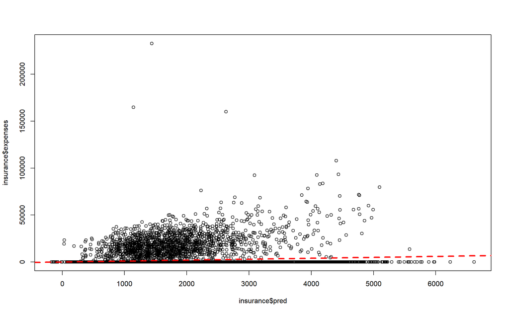

```r
plot(insurance$pred, insurance$expenses)
abline(a=0, b=1, col="red", lwd=3, lty=2)
```

## Making Predictions with a regression model

```r
predict(ins_model2,
        data.frame(age=30, age2=30^2, geo_area='rural',
                   vehicle_type='truck', est_value=25000,
                   miles_driven=14000, college_grad_ind=0,
                   speeding_ticket_ind=0, hard_braking_ind=0,
                   late_driving_ind=0, clean_driving_ind=1))
```

```
       1
1015.059
```

```r
predict(ins_model2,
        data.frame(age=30, age2=30^2, geo_area='rural',
                   vehicle_type='truck', est_value=25000,
                   miles_driven=14000, college_grad_ind=0,
                   speeding_ticket_ind=0, hard_braking_ind=0,
                   late_driving_ind=0, clean_driving_ind=0))
```

```
       1
1247.903
```

```r
predict(ins_model2,
        data.frame(age=30, age2=30^2, geo_area='rural',
                   vehicle_type='truck', est_value=25000,
                   miles_driven=24000, college_grad_ind=0,
                   speeding_ticket_ind=0, hard_braking_ind=0,
                   late_driving_ind=0, clean_driving_ind=0))
```

```
       1
2435.384
```

# Housing Example

Predicting house prices using Boston housing data

## Some information about the data

- The Boston housing dataset is a classic dataset used in regression analysis
- It contains 506 observations on housing prices in the [Boston area](https://www.law.berkeley.edu/files/Hedonic.PDF)
- The dataset has 12(3) features and 1 target variable
- The features include:
  - crim: per capita crime rate by town
  - zn: proportion of residential land zoned for lots over 25,000 sq. ft.
  - indus: proportion of non-retail business acres per town
  - chas: Charles River dummy variable (= 1 if tract bounds river; 0 otherwise)
  - nox: nitric oxides concentration (parts per 10 million)
  - rm: average number of rooms per dwelling
  - age: proportion of owner-occupied units built prior to 1940
  - dis: weighted distances to five Boston employment centers
  - rad: index of accessibility to radial highways
  - tax: full-value property-tax rate per $10,000
  - ptratio: pupil-teacher ratio by town
  - lstat: % lower status of the population
- The target variable is the median value of owner-occupied homes in $1000s (medv)

## Load the data

```r
library(tidyverse)

boston_df<- read_csv("https://raw.githubusercontent.com/kwan-MSDA/MSDA7003/main/Boston.csv")

str(boston_df)
```

```
spc_tbl_ [506 × 14] (S3: spec_tbl_df/tbl_df/tbl/data.frame)
 $ ...1   : num [1:506] 1 2 3 4 5 6 7 8 9 10 ...
 $ crim   : num [1:506] 0.00632 0.02731 0.02729 0.03237 0.06905 ...
 $ zn     : num [1:506] 18 0 0 0 0 0 12.5 12.5 12.5 12.5 ...
 $ indus  : num [1:506] 2.31 7.07 7.07 2.18 2.18 2.18 7.87 7.87 7.87 7.87 ...
 $ chas   : num [1:506] 0 0 0 0 0 0 0 0 0 0 ...
 $ nox    : num [1:506] 0.538 0.469 0.469 0.458 0.458 0.458 0.524 0.524 0.524 0.524 ...
 $ rm     : num [1:506] 6.58 6.42 7.18 7 7.15 ...
 $ age    : num [1:506] 65.2 78.9 61.1 45.8 54.2 58.7 66.6 96.1 100 85.9 ...
 $ dis    : num [1:506] 4.09 4.97 4.97 6.06 6.06 ...
 $ rad    : num [1:506] 1 2 2 3 3 3 5 5 5 5 ...
 $ tax    : num [1:506] 296 242 242 222 222 222 311 311 311 311 ...
 $ ptratio: num [1:506] 15.3 17.8 17.8 18.7 18.7 18.7 15.2 15.2 15.2 15.2 ...
 $ lstat  : num [1:506] 4.98 9.14 4.03 2.94 5.33 ...
 $ medv   : num [1:506] 24 21.6 34.7 33.4 36.2 28.7 22.9 27.1 16.5 18.9 ...
 - attr(*, "spec")=
  .. cols(
  ..   ...1 = col_double(),
  ..   crim = col_double(),
  ..   zn = col_double(),
  ..   indus = col_double(),
  ..   chas = col_double(),
  ..   nox = col_double(),
  ..   rm = col_double(),
  ..   age = col_double(),
  ..   dis = col_double(),
  ..   rad = col_double(),
  ..   tax = col_double(),
  ..   ptratio = col_double(),
  ..   lstat = col_double(),
  ..   medv = col_double()
  .. )
 - attr(*, "problems")=<externalptr>
```

```r
head(boston_df)
```

```
# A tibble: 6 × 14
   ...1    crim    zn indus  chas   nox    rm   age   dis   rad   tax ptratio
  <dbl>   <dbl> <dbl> <dbl> <dbl> <dbl> <dbl> <dbl> <dbl> <dbl> <dbl>   <dbl>
1     1 0.00632    18  2.31     0 0.538  6.58  65.2  4.09     1   296    15.3
2     2 0.0273      0  7.07     0 0.469  6.42  78.9  4.97     2   242    17.8
3     3 0.0273      0  7.07     0 0.469  7.18  61.1  4.97     2   242    17.8
4     4 0.0324      0  2.18     0 0.458  7.00  45.8  6.06     3   222    18.7
5     5 0.0690      0  2.18     0 0.458  7.15  54.2  6.06     3   222    18.7
6     6 0.0298      0  2.18     0 0.458  6.43  58.7  6.06     3   222    18.7
# ℹ 2 more variables: lstat <dbl>, medv <dbl>
```

```r
summary(boston_df)
```

```
      ...1            crim                zn             indus
 Min.   :  1.0   Min.   : 0.00632   Min.   :  0.00   Min.   : 0.46
 1st Qu.:127.2   1st Qu.: 0.08205   1st Qu.:  0.00   1st Qu.: 5.19
 Median :253.5   Median : 0.25651   Median :  0.00   Median : 9.69
 Mean   :253.5   Mean   : 3.61352   Mean   : 11.36   Mean   :11.14
 3rd Qu.:379.8   3rd Qu.: 3.67708   3rd Qu.: 12.50   3rd Qu.:18.10
 Max.   :506.0   Max.   :88.97620   Max.   :100.00   Max.   :27.74
      chas              nox               rm             age
 Min.   :0.00000   Min.   :0.3850   Min.   :3.561   Min.   :  2.90
 1st Qu.:0.00000   1st Qu.:0.4490   1st Qu.:5.886   1st Qu.: 45.02
 Median :0.00000   Median :0.5380   Median :6.208   Median : 77.50
 Mean   :0.06917   Mean   :0.5547   Mean   :6.285   Mean   : 68.57
 3rd Qu.:0.00000   3rd Qu.:0.6240   3rd Qu.:6.623   3rd Qu.: 94.08
 Max.   :1.00000   Max.   :0.8710   Max.   :8.780   Max.   :100.00
      dis              rad              tax           ptratio
 Min.   : 1.130   Min.   : 1.000   Min.   :187.0   Min.   :12.60
 1st Qu.: 2.100   1st Qu.: 4.000   1st Qu.:279.0   1st Qu.:17.40
 Median : 3.207   Median : 5.000   Median :330.0   Median :19.05
 Mean   : 3.795   Mean   : 9.549   Mean   :408.2   Mean   :18.46
 3rd Qu.: 5.188   3rd Qu.:24.000   3rd Qu.:666.0   3rd Qu.:20.20
 Max.   :12.127   Max.   :24.000   Max.   :711.0   Max.   :22.00
     lstat            medv
 Min.   : 1.73   Min.   : 5.00
 1st Qu.: 6.95   1st Qu.:17.02
 Median :11.36   Median :21.20
 Mean   :12.65   Mean   :22.53
 3rd Qu.:16.95   3rd Qu.:25.00
 Max.   :37.97   Max.   :50.00
```

```r
boston_df<- boston_df %>% select(-c("...1"))
```

## Explore the data

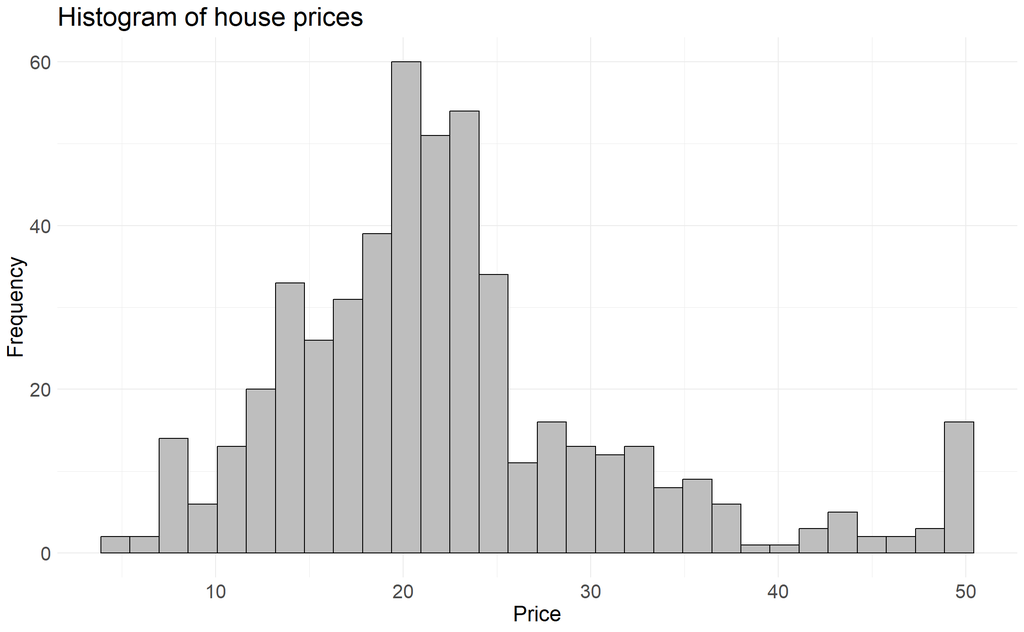

```r
library(ggplot2)

ggplot(boston_df, aes(x=medv)) +
  geom_histogram(fill='grey', color="black")+
  labs(title="Histogram of house prices",
        x= "Price", y="Frequency") +
  theme_minimal()+
  theme(axis.text.x = element_text(size = 16),
        axis.text.y = element_text(size = 16),
        axis.title.x = element_text(size = 18),
        axis.title.y = element_text(size = 18),
        plot.title = element_text(size = 22))
```

## Explore the data

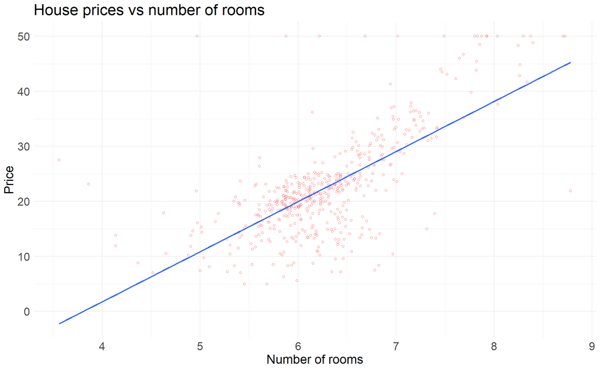

```r
library(ggplot2)

ggplot(boston_df, aes(x=rm, y=medv)) +
  geom_point(shape=1, alpha=0.6, color="red") +
  geom_smooth(method="lm", se=FALSE) +
  labs(title="House prices vs number of rooms",
        x= "Number of rooms", y="Price") +
  theme_minimal()+
  theme(axis.text.x = element_text(size = 16),
        axis.text.y = element_text(size = 16),
        axis.title.x = element_text(size = 18),
        axis.title.y = element_text(size = 18),
        plot.title = element_text(size = 22))
```

## Explore the data

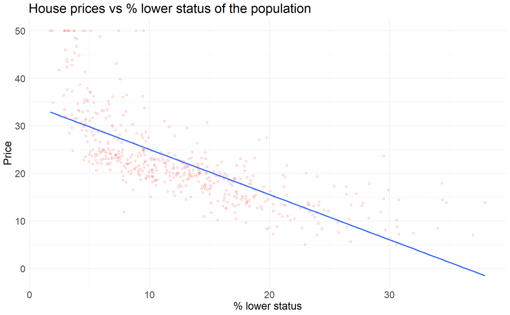

```r
library(ggplot2)

ggplot(boston_df, aes(x=lstat, y=medv)) +
  geom_point(shape=1, alpha=0.6, color="red") +
  geom_smooth(method="lm", se=FALSE, lwd=1) +
  labs(title="House prices vs % lower status of the population",
        x= "% lower status", y="Price") +
  theme_minimal()+
  theme(axis.text.x = element_text(size = 16),
        axis.text.y = element_text(size = 16),
        axis.title.x = element_text(size = 18),
        axis.title.y = element_text(size = 18),
        plot.title = element_text(size = 22))
```

## Explore the data

```r
cor(boston_df)
```

```
               crim          zn       indus         chas         nox
crim     1.00000000 -0.20046922  0.40658341 -0.055891582  0.42097171
zn      -0.20046922  1.00000000 -0.53382819 -0.042696719 -0.51660371
indus    0.40658341 -0.53382819  1.00000000  0.062938027  0.76365145
chas    -0.05589158 -0.04269672  0.06293803  1.000000000  0.09120281
nox      0.42097171 -0.51660371  0.76365145  0.091202807  1.00000000
rm      -0.21924670  0.31199059 -0.39167585  0.091251225 -0.30218819
age      0.35273425 -0.56953734  0.64477851  0.086517774  0.73147010
dis     -0.37967009  0.66440822 -0.70802699 -0.099175780 -0.76923011
rad      0.62550515 -0.31194783  0.59512927 -0.007368241  0.61144056
tax      0.58276431 -0.31456332  0.72076018 -0.035586518  0.66802320
ptratio  0.28994558 -0.39167855  0.38324756 -0.121515174  0.18893268
lstat    0.45562148 -0.41299457  0.60379972 -0.053929298  0.59087892
medv    -0.38830461  0.36044534 -0.48372516  0.175260177 -0.42732077
                 rm         age         dis          rad         tax    ptratio
crim    -0.21924670  0.35273425 -0.37967009  0.625505145  0.58276431  0.2899456
zn       0.31199059 -0.56953734  0.66440822 -0.311947826 -0.31456332 -0.3916785
indus   -0.39167585  0.64477851 -0.70802699  0.595129275  0.72076018  0.3832476
chas     0.09125123  0.08651777 -0.09917578 -0.007368241 -0.03558652 -0.1215152
nox     -0.30218819  0.73147010 -0.76923011  0.611440563  0.66802320  0.1889327
rm       1.00000000 -0.24026493  0.20524621 -0.209846668 -0.29204783 -0.3555015
age     -0.24026493  1.00000000 -0.74788054  0.456022452  0.50645559  0.2615150
dis      0.20524621 -0.74788054  1.00000000 -0.494587930 -0.53443158 -0.2324705
rad     -0.20984667  0.45602245 -0.49458793  1.000000000  0.91022819  0.4647412
tax     -0.29204783  0.50645559 -0.53443158  0.910228189  1.00000000  0.4608530
ptratio -0.35550149  0.26151501 -0.23247054  0.464741179  0.46085304  1.0000000
lstat   -0.61380827  0.60233853 -0.49699583  0.488676335  0.54399341  0.3740443
medv     0.69535995 -0.37695457  0.24992873 -0.381626231 -0.46853593 -0.5077867
             lstat       medv
crim     0.4556215 -0.3883046
zn      -0.4129946  0.3604453
indus    0.6037997 -0.4837252
chas    -0.0539293  0.1752602
nox      0.5908789 -0.4273208
rm      -0.6138083  0.6953599
age      0.6023385 -0.3769546
dis     -0.4969958  0.2499287
rad      0.4886763 -0.3816262
tax      0.5439934 -0.4685359
ptratio  0.3740443 -0.5077867
lstat    1.0000000 -0.7376627
medv    -0.7376627  1.0000000
```

## Explore the data

```r
library(GGally)

# heatmap of the correlation matrix
ggcorr(boston_df, label = TRUE, label_size = 4, label_round = 2)
```

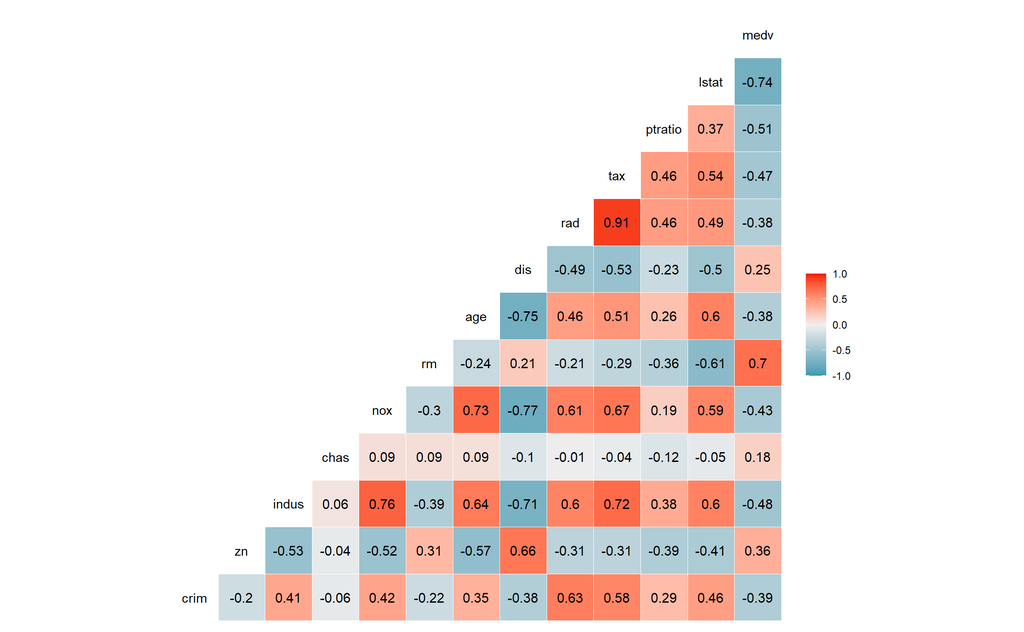

## Train a regression model

```r
boston_model1<- lm(medv ~ lstat, data=boston_df)

summary(boston_model1)
```

```
Call:
lm(formula = medv ~ lstat, data = boston_df)

Residuals:
    Min      1Q  Median      3Q     Max
-15.168  -3.990  -1.318   2.034  24.500

Coefficients:
            Estimate Std. Error t value            Pr(>|t|)
(Intercept) 34.55384    0.56263   61.41 <0.0000000000000002 ***
lstat       -0.95005    0.03873  -24.53 <0.0000000000000002 ***
---
Signif. codes:  0 '***' 0.001 '**' 0.01 '*' 0.05 '.' 0.1 ' ' 1

Residual standard error: 6.216 on 504 degrees of freedom
Multiple R-squared:  0.5441,    Adjusted R-squared:  0.5432
F-statistic: 601.6 on 1 and 504 DF,  p-value: < 0.00000000000000022
```

```r
names(boston_model1)
```

```
 [1] "coefficients"  "residuals"     "effects"       "rank"
 [5] "fitted.values" "assign"        "qr"            "df.residual"
 [9] "xlevels"       "call"          "terms"         "model"
```

```r
coef(boston_model1)
```

```
(Intercept)       lstat
 34.5538409  -0.9500494
```

## Train a regression model

### Visualize the model

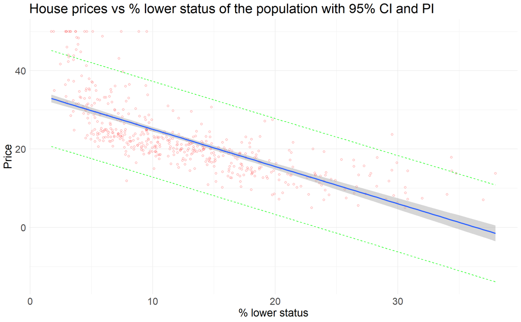

```r
pred_conf<- predict(boston_model1, interval="confidence", level = 0.95)
pred_pred<- predict(boston_model1, interval="prediction", level = 0.95)

ggplot(boston_df, aes(x=lstat, y=medv)) +
  geom_point(shape=1, alpha=0.6, color="red") +
  geom_smooth(method="lm", se=TRUE, lwd=1) +
  geom_line(aes(y=pred_pred[,2]), color="green", linetype="dashed") +
  geom_line(aes(y=pred_pred[,3]), color="green", linetype="dashed") +
  labs(title="House prices vs % lower status of the population with 95% CI and PI",
        x= "% lower status", y="Price") +
  theme_minimal()+
  theme(axis.text.x = element_text(size = 16),
        axis.text.y = element_text(size = 16),
        axis.title.x = element_text(size = 18),
        axis.title.y = element_text(size = 18),
        plot.title = element_text(size = 22))
```

## Train a regression model

### Visualize the model

let us add one more feature to the model

```r
boston_model2<- lm(medv ~ lstat + chas, data=boston_df)

summary(boston_model2)
```

```
Call:
lm(formula = medv ~ lstat + chas, data = boston_df)

Residuals:
    Min      1Q  Median      3Q     Max
-14.782  -3.798  -1.286   1.769  24.870

Coefficients:
            Estimate Std. Error t value             Pr(>|t|)
(Intercept) 34.09412    0.56067  60.809 < 0.0000000000000002 ***
lstat       -0.94061    0.03804 -24.729 < 0.0000000000000002 ***
chas         4.91998    1.06939   4.601           0.00000534 ***
---
Signif. codes:  0 '***' 0.001 '**' 0.01 '*' 0.05 '.' 0.1 ' ' 1

Residual standard error: 6.095 on 503 degrees of freedom
Multiple R-squared:  0.5626,    Adjusted R-squared:  0.5608
F-statistic: 323.4 on 2 and 503 DF,  p-value: < 0.00000000000000022
```

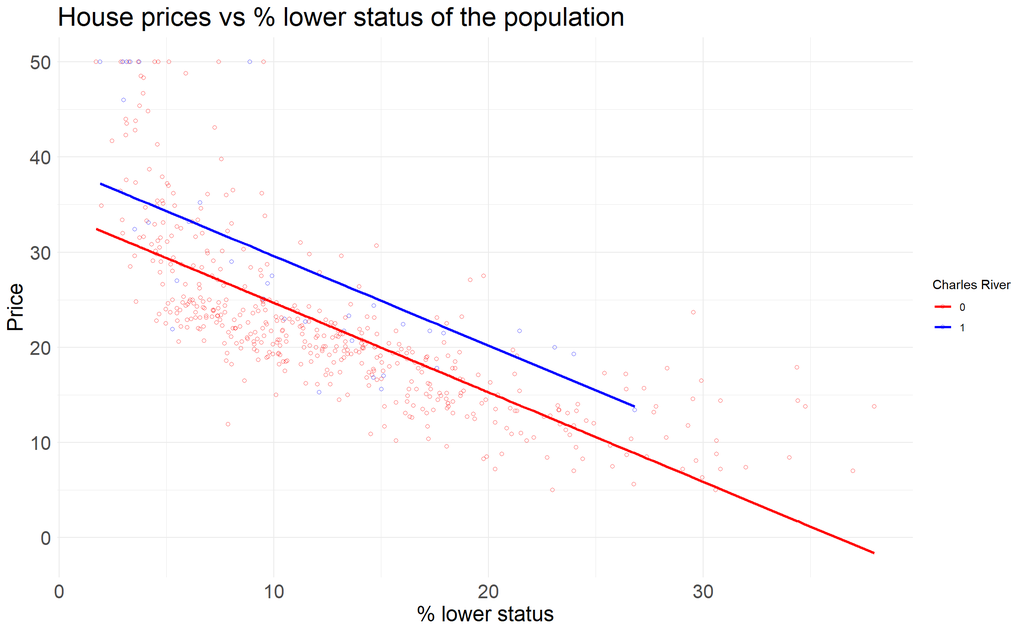

```r
a<- predict(boston_model2, interval="confidence", level = 0)[, "fit"]


datlm<- cbind(boston_df, a)

ggplot(boston_df, aes(x=lstat, y=medv, color=as.factor(chas))) +
  geom_point(shape=1, alpha=0.6) +
  geom_line(data=datlm, aes(y=a), size=1) +
  labs(title="House prices vs % lower status of the population",
        x= "% lower status", y="Price") +
  scale_color_manual(name="Charles River", values=c("red", "blue"))+
  theme_minimal()+
  theme(axis.text.x = element_text(size = 16),
        axis.text.y = element_text(size = 16),
        axis.title.x = element_text(size = 18),
        axis.title.y = element_text(size = 18),
        plot.title = element_text(size = 22))
```

## Train a regression model

### interaaction term

let us add an interaction term to the model

```r
boston_model3<- lm(medv ~ lstat + chas +lstat:chas, data=boston_df)

summary(boston_model3)
```

```
Call:
lm(formula = medv ~ lstat + chas + lstat:chas, data = boston_df)

Residuals:
    Min      1Q  Median      3Q     Max
-14.657  -3.787  -1.289   1.644  24.953

Coefficients:
            Estimate Std. Error t value             Pr(>|t|)
(Intercept) 33.76716    0.57018  59.222 < 0.0000000000000002 ***
lstat       -0.91498    0.03897 -23.478 < 0.0000000000000002 ***
chas         9.82513    2.10320   4.672           0.00000384 ***
lstat:chas  -0.43288    0.16017  -2.703              0.00711 **
---
Signif. codes:  0 '***' 0.001 '**' 0.01 '*' 0.05 '.' 0.1 ' ' 1

Residual standard error: 6.057 on 502 degrees of freedom
Multiple R-squared:  0.5688,    Adjusted R-squared:  0.5663
F-statistic: 220.8 on 3 and 502 DF,  p-value: < 0.00000000000000022
```

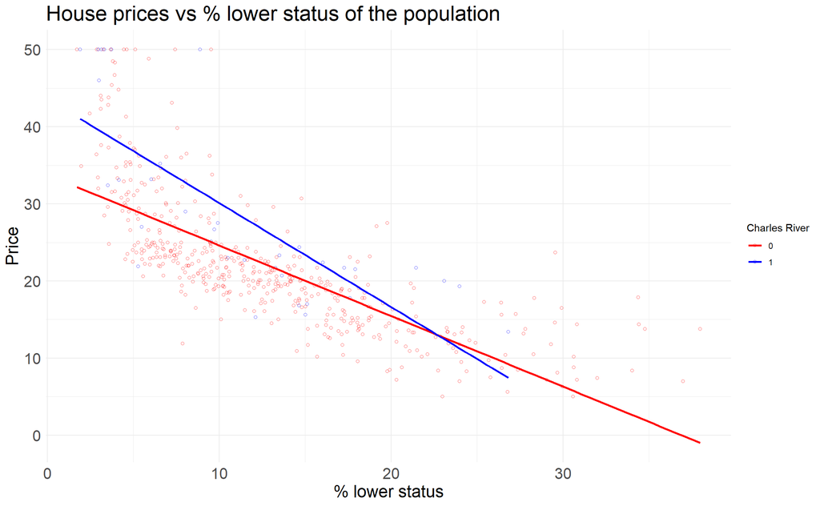

```r
b2<- ggplot(boston_df, aes(x=lstat, y=medv, color=as.factor(chas))) +
  geom_point(shape=1, alpha=0.6) +
  geom_smooth(method="lm", se=FALSE, lwd=1) +
  labs(title="House prices vs % lower status of the population",
        x= "% lower status", y="Price") +
  scale_color_manual(name="Charles River", values=c("red", "blue"))+
  theme_minimal()+
  theme(axis.text.x = element_text(size = 16),
        axis.text.y = element_text(size = 16),
        axis.title.x = element_text(size = 18),
        axis.title.y = element_text(size = 18),
        plot.title = element_text(size = 22))

b2
```

## Train a regression model

### Non-linear transformation of predictors

```r
boston_model4<- lm(medv ~ lstat + I(lstat^2), data=boston_df)

summary(boston_model4)
```

```
Call:
lm(formula = medv ~ lstat + I(lstat^2), data = boston_df)

Residuals:
     Min       1Q   Median       3Q      Max
-15.2834  -3.8313  -0.5295   2.3095  25.4148

Coefficients:
             Estimate Std. Error t value            Pr(>|t|)
(Intercept) 42.862007   0.872084   49.15 <0.0000000000000002 ***
lstat       -2.332821   0.123803  -18.84 <0.0000000000000002 ***
I(lstat^2)   0.043547   0.003745   11.63 <0.0000000000000002 ***
---
Signif. codes:  0 '***' 0.001 '**' 0.01 '*' 0.05 '.' 0.1 ' ' 1

Residual standard error: 5.524 on 503 degrees of freedom
Multiple R-squared:  0.6407,    Adjusted R-squared:  0.6393
F-statistic: 448.5 on 2 and 503 DF,  p-value: < 0.00000000000000022
```

```r
boston_model5<- lm(medv ~ poly(lstat, 5), data=boston_df)

summary(boston_model5)
```

```
Call:
lm(formula = medv ~ poly(lstat, 5), data = boston_df)

Residuals:
     Min       1Q   Median       3Q      Max
-13.5433  -3.1039  -0.7052   2.0844  27.1153

Coefficients:
                 Estimate Std. Error t value             Pr(>|t|)
(Intercept)       22.5328     0.2318  97.197 < 0.0000000000000002 ***
poly(lstat, 5)1 -152.4595     5.2148 -29.236 < 0.0000000000000002 ***
poly(lstat, 5)2   64.2272     5.2148  12.316 < 0.0000000000000002 ***
poly(lstat, 5)3  -27.0511     5.2148  -5.187           0.00000031 ***
poly(lstat, 5)4   25.4517     5.2148   4.881           0.00000142 ***
poly(lstat, 5)5  -19.2524     5.2148  -3.692             0.000247 ***
---
Signif. codes:  0 '***' 0.001 '**' 0.01 '*' 0.05 '.' 0.1 ' ' 1

Residual standard error: 5.215 on 500 degrees of freedom
Multiple R-squared:  0.6817,    Adjusted R-squared:  0.6785
F-statistic: 214.2 on 5 and 500 DF,  p-value: < 0.00000000000000022
```

```r
anova(boston_model4, boston_model5)
```

```
Analysis of Variance Table

Model 1: medv ~ lstat + I(lstat^2)
Model 2: medv ~ poly(lstat, 5)
  Res.Df   RSS Df Sum of Sq      F             Pr(>F)
1    503 15347
2    500 13597  3    1750.2 21.453 0.0000000000004372 ***
---
Signif. codes:  0 '***' 0.001 '**' 0.01 '*' 0.05 '.' 0.1 ' ' 1
```

## Train a regression model

### Non-linear transformation of predictors

Let us visualize the models

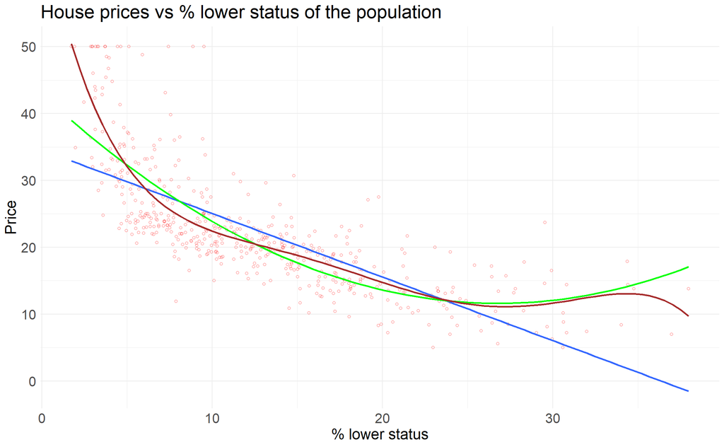

```r
ggplot(boston_df, aes(x=lstat, y=medv)) +
  geom_point(shape=1, alpha=0.6, color="red") +
  geom_smooth(method="lm", se=FALSE, lwd=1) +
  geom_smooth(method="lm", formula = y ~ poly(x, 2), se=FALSE, lwd=1, color="green") +
  geom_smooth(method="lm", formula = y ~ poly(x, 5), se=FALSE, lwd=1, color="brown") +
  labs(title="House prices vs % lower status of the population",
        x= "% lower status", y="Price") +
  theme_minimal()+
  theme(axis.text.x = element_text(size = 16),
        axis.text.y = element_text(size = 16),
        axis.title.x = element_text(size = 18),
        axis.title.y = element_text(size = 18),
        plot.title = element_text(size = 22))
```

## Train a regression model

### Full Model

## Train a regression model

### Full Model

```r
library(modelsummary)
library(kableExtra)
library(gt)

boston_model6<- lm(medv ~ ., data=boston_df)

models<- list(
  "Basic Model"= boston_model1,
  "More Complicated"=boston_model2,
  "Full Model"= boston_model6)

summary_table<- modelsummary(models, stars = TRUE,
             gof_digits = 3,
             gof_map = c("nobs", "r.squared", "adj.r.squared", "fstatistic", "p.value"),
             statistic = "({std.error})",
             #title = "Regression Models for Boston Housing Data",
             output = "kableExtra")

summary_table2 <-  summary_table %>%
  kable_styling(full_width = FALSE, position = "center", latex_options = c("striped", "hold_position")) %>%
  add_header_above(c(" " = 1, "Regression Models for Boston Housing Data" = 3)) %>%
  footnote(general = "This table presents the regression results for the Boston housing data.",
           footnote_as_chunk = TRUE)
#   row_spec(0, extra_css = "border-bottom: 0px;") %>%
#   column_spec(1, extra_css = "border-right: 0px;")
#
# # Save the table as an HTML file
# save_kable(summary_table, "table_housing.html")

summary_table2
```

|  | Regression Models for Boston Housing Data Basic Model | Regression Models for Boston Housing Data More Complicated | Regression Models for Boston Housing Data Full Model |
| --- | --- | --- | --- |
| (Intercept) | 34.554*** | 34.094*** | 41.617*** |
|  | (0.563) | (0.561) | (4.936) |
| lstat | −0.950*** | −0.941*** | −0.552*** |
|  | (0.039) | (0.038) | (0.051) |
| chas |  | 4.920*** | 2.840** |
|  |  | (1.069) | (0.870) |
| crim |  |  | −0.121*** |
|  |  |  | (0.033) |
| zn |  |  | 0.047*** |
|  |  |  | (0.014) |
| indus |  |  | 0.013 |
|  |  |  | (0.062) |
| nox |  |  | −18.758*** |
|  |  |  | (3.851) |
| rm |  |  | 3.658*** |
|  |  |  | (0.420) |
| age |  |  | 0.004 |
|  |  |  | (0.013) |
| dis |  |  | −1.491*** |
|  |  |  | (0.202) |
| rad |  |  | 0.289*** |
|  |  |  | (0.067) |
| tax |  |  | −0.013*** |
|  |  |  | (0.004) |
| ptratio |  |  | −0.938*** |
|  |  |  | (0.132) |
| Num.Obs. | 506 | 506 | 506 |
| R2 | 0.544 | 0.563 | 0.734 |
| R2 Adj. | 0.543 | 0.561 | 0.728 |

+ p < 0.1, * p < 0.05, ** p < 0.01, *** p < 0.001  
Note: This table presents the regression results for the Boston housing data.

## References

James, G., D. Witten, T. Hastie, and R. Tibshirani. 2023. *An Introduction to Statistical Learning with Applications in r*. Second edition. Springer.

Lantz, Brett. 2023. *Machine Learning with r : Learn Techniques for Building and Improving Machine Learning Models, from Data Preparation to Model Tuning, Evaluation, and Working with Big Data*. Fourth edition. Expert Insight. Birmingham, UK: Packt Publishing Limited.